PVD · M09 Dashboards · Folha de Referência Rápida

# Looker Studio — Roubo de Veículos no Sudeste

Guia objetivo sincronizado com o painel validado SINESP VDE: conexão, 4 fórmulas, montagem de 1 página e gabarito no Google Sheets.

[Abrir Looker Studio](https://lookerstudio.google.com/) [Planilha sinesp_uf_mensal](https://docs.google.com/spreadsheets/d/1tiSt45GO9qlWjm3iWxpkVTlcULahEdxPmdpDLYzLIRg/edit?usp=drivesdk)

## 1 Conexão e Tipos da Fonte

ID: `1tiSt45GO9qlWjm3iWxpkVTlcULahEdxPmdpDLYzLIRg`

**Planilha pública oficial (`sinesp_uf_mensal` · página `sinesp_uf_mensal.csv`):** `https://docs.google.com/spreadsheets/d/1tiSt45GO9qlWjm3iWxpkVTlcULahEdxPmdpDLYzLIRg/edit?usp=drivesdk`

### Importar direto pela guia `URL` (URL completa ou ID)

1. Copie a **URL completa** ou apenas o **ID** acima.
2. No Looker Studio (`lookerstudio.google.com`), clique em **Criar → Relatório** e escolha o conector **Google Planilhas** *(na 1ª vez, clique em **AUTORIZAR**)*.
3. Na barra esquerda, não procure só em *TODOS OS ITENS*: clique na guia **`URL`** e, em **Colar ID ou URL da planilha → URL ou ID da planilha**, cole a URL ou o ID.
4. Confirme *“A planilha `sinesp_uf_mensal` foi encontrada.”*, selecione a **Página** **`sinesp_uf_mensal.csv`**, mantenha **`Usar a primeira linha como cabeçalhos`** e **`Incluir células ocultas e filtradas`** marcados e clique em **Adicionar** *(ou **CONECTAR**)* → **Adicionar ao relatório**.
5. Ajuste os tipos abaixo em **Recurso → Gerenciar fontes de dados adicionadas → Editar**.

### Alternativa recomendada (para Tabela Dinâmica)

Como a planilha pública está em modo **Leitor**, abra o link e clique em **Arquivo → Fazer uma cópia** para salvar `sinesp_uf_mensal` no seu próprio Drive.

Assim ela também aparece em **TODOS OS ITENS** no conector **Google Planilhas** e libera a criação da **Tabela dinâmica** na Seção 4.

[figure not shown]

**Importação via URL ou ID:** conector **Google Planilhas** → guia **`URL`** → campo **`URL ou ID da planilha`** → página **`sinesp_uf_mensal.csv`** → **`CONECTAR`** / **Adicionar**.

[output not shown]

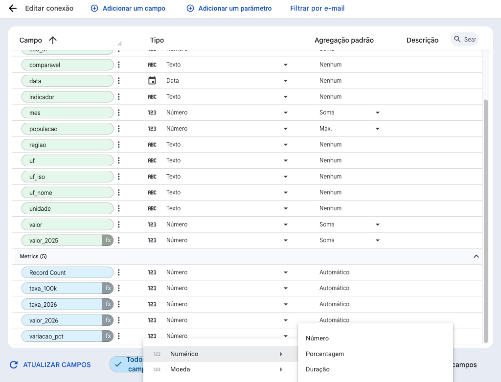

**Fonte configurada:** `data` como **Data**, `populacao` em **Máx.**, `valor` em **Soma** e seleção de `Numérico → Porcentagem` em `variacao_pct`.

## 2 Fórmulas Exatas e Filtro do Recorte

Campos: **Dados → + Adicionar um campo** · Filtro: **Página → Configurações da página atual**

valor_2025

Tipo: **Número** (0 casas) · roubos em 2025

```
SUM(CASE WHEN ano = 2025 THEN valor ELSE 0 END)
```

Soma a coluna `valor` só nas linhas de 2025. O `CASE` troca por 0 o valor das linhas de outros anos, e o `SUM` soma o resto.

V_{2025} = \sum_{\text{ano}=2025} \text{valor}

No recorte, de jan a set: **40.022** roubos.

valor_2026

Tipo: **Número** (0 casas) · roubos em 2026

```
SUM(CASE WHEN ano = 2026 THEN valor ELSE 0 END)
```

A mesma conta, agora só nas linhas de 2026.

V_{2026} = \sum_{\text{ano}=2026} \text{valor}

No recorte, de jan a set: **32.948** roubos.

variacao_pct

Tipo: **Numérico → Porcentagem** (1 casa) · Δ% 2026 × 2025

```
SUM(CASE WHEN ano = 2026 THEN valor ELSE 0 END) / SUM(CASE WHEN ano = 2025 THEN valor ELSE 0 END) - 1
```

Divide o total de 2026 pelo de 2025 e tira 1. O resultado é a variação relativa: negativo quando caiu, positivo quando subiu.

\Delta\% = \frac{V_{2026}}{V_{2025}} - 1

`32.948 ÷ 40.022 − 1 = −0,177`, que o formato Porcentagem mostra como **−17,7%**.

taxa_2026

Tipo: **Número** (2 casas) · exata por UF e na linha Sudeste

```
SUM(CASE WHEN ano = 2026 THEN valor ELSE 0 END) / (SUM(CASE WHEN ano = 2026 THEN populacao ELSE 0 END) / COUNT_DISTINCT(CASE WHEN ano = 2026 THEN mes ELSE NULL END)) * 100000
```

Roubos por 100 mil habitantes. A população aparece repetida em cada mês de cada UF, então somar `populacao` e dividir pelo número de meses (`COUNT_DISTINCT`) devolve a população uma vez só, por UF ou somada no Sudeste.

\begin{gathered} \text{taxa} = \frac{V_{2026}}{P} \times 100\,000 \\[6pt] P = \frac{\displaystyle\sum_{\text{ano}=2026} \text{populacao}}{n_{\text{meses}}} \end{gathered}

Sudeste: `32.948 ÷ 89.015.421 × 100.000` = **37,01** roubos por 100 mil habitantes.

**Dica opcional (eixo X):** `mes` exibe `1..9`; para exibir `jan..set` no Gráfico 1, crie `mes_nome` com `CASE WHEN mes = 1 THEN "jan" ... WHEN mes = 9 THEN "set" END` e ordene por `MÍN(mes)`.

**Armadilha do denominador na linha `Total` (`Sudeste`):** usar `MAX(populacao)` acerta cada UF isolada, mas no Total pega só a maior UF (**SP = 46.179.008**) e gera a taxa falsa **`71,35`** (`32.948 ÷ 46.179.008 × 100 mil`). Com **1 indicador** filtrado, dividir pela contagem de meses `COUNT_DISTINCT(CASE WHEN ano = 2026 THEN mes ELSE NULL END)` soma as 4 UFs (**`89.015.421`**) e devolve o valor exato **`37,01`**.

### Filtro fixo da página (`Recorte Sudeste Roubo`)

Em **Página → Configurações da página atual → Adicionar filtro → Criar filtro**, una 3 cláusulas com **AND**:

- `Incluir` · `indicador` · `Igual a (=)` · `Roubo de veículo`
- `Incluir` · `regiao` · `Igual a (=)` · `Sudeste`
- `Incluir` · `mes` · `Menor ou igual a (<=)` · `9`

**Dica certeira:** ao digitar o texto, **clique no chip sugerido** — apertar `Tab` falha e zera o painel com *“Não há dados”*. Usar `mes <= 9` evita conflitos de Texto/Booleano em `comparavel`.

### Por que `Controle deslizante` (`mes`) e não `Controle de período`?

O `Controle de período` filtraria só 2026 e descartaria as linhas de `2025` antes do cálculo de `valor_2025` e `variacao_pct`. O controle deslizante em `mes` (`1..9`) filtra **os dois anos juntos** nos mesmos meses.

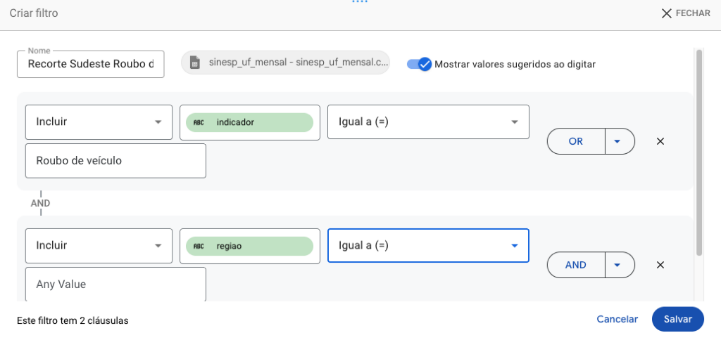

**Editor Criar filtro:** combine as 3 cláusulas com `AND` (`indicador`, `regiao = Sudeste` e `mes <= 9`) e clique sempre no chip sugerido antes de salvar.

## 3 Montagem dos Blocos no Painel (1 Página)

Alinhe o topo com **Organizar → Alinhar / Distribuir** · Compartilhe em **Leitor**

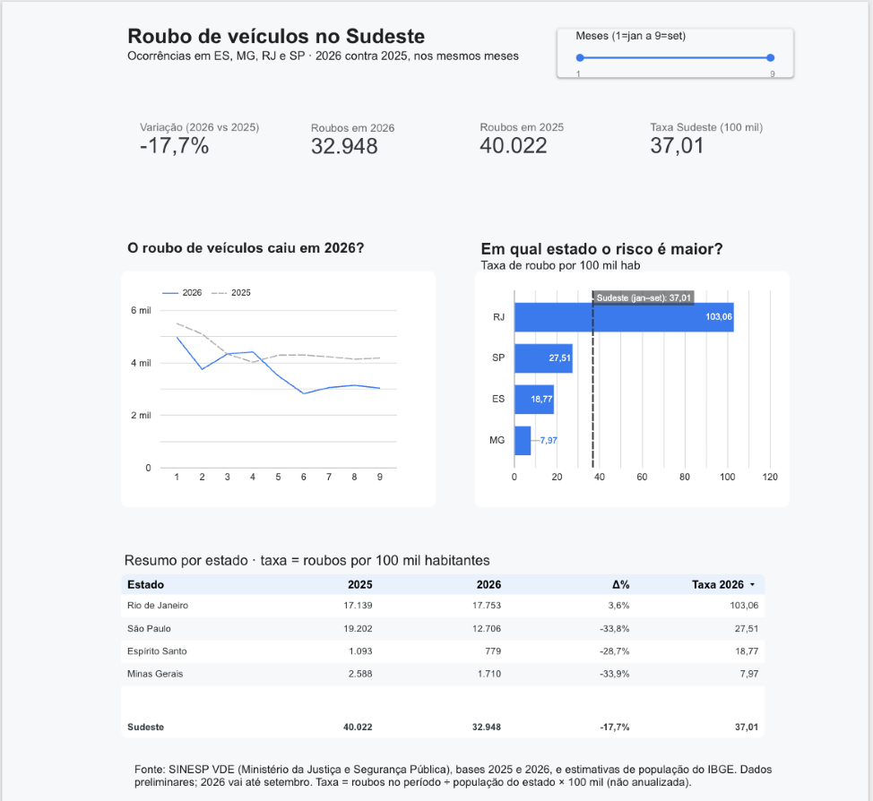

**Painel completo em modo Leitura (`Meses = 1..9`):** cabeçalho com slider, faixa dos 4 Big Numbers, dois gráficos lado a lado com títulos acima, tabela-resumo (`Sudeste = 37,01`) e rodapé metodológico.

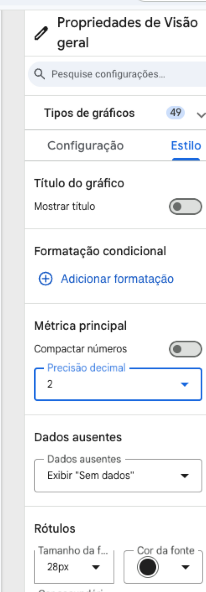

**Estilo dos Big Numbers:** em *Métrica principal*, **desative `Compactar números`** e ajuste `Precisão decimal = 2` em `Taxa Sudeste`.

[output not shown]

**Comportamento esperado no Looker Studio (leia antes de entregar):**

- **Linha de referência estática (`37,01`):** ao mover o slider para `1..6`, o Big Number `Taxa Sudeste` e a linha `Sudeste` da Tabela recalculam para **`26,69`**, mas a linha vertical tracejada no Gráfico 2 segue fixa em `37,01`. *(Para torná-la dinâmica, seria necessário adicionar a média regional como série calculada.)*
- **Eixo X `1..9` e aparência nativa:** o eixo X exibe `1..9` por padrão (`mes_nome` é opcional), barras usam cor única `#1A73E8` + linha vertical, `Δ%` exibe sinal `-` sem setas coloridas, e a tabela deixa um pequeno vão branco antes de `Sudeste`.

## 4 Conferência no Google Sheets, Gabarito e 5 Erros Comuns

Valide os números na planilha antes de compartilhar o link

**Conferência em 3 passos no Google Sheets** (na sua cópia via **Arquivo → Fazer uma cópia**, clique em **Inserir → Tabela dinâmica**):

1. **Linhas:** `uf_nome` | **Colunas:** `ano` | **Valores:** `valor` (`SOMA`) e `populacao` (`MÁX`).
2. **Filtros:** `indicador = Roubo de veículo`, `regiao = Sudeste` e `mes <= 9`.
3. **Taxa do Sudeste:** `SOMA(valor) ÷ SOMA(populacao das 4 UFs) × 100.000` = `32.948 ÷ 89.015.421 × 100.000` = **`37,01`**.

Roubos em 2025 (jan–set)

40.022

Taxa 2025: 45,06

Roubos em 2026 (jan–set)

32.948

Pop. 2026: 89.015.421

Variação Δ% (2026 vs 2025)

−17,7%

Exato: −17,68%

Taxa Sudeste (100 mil)

37,01

Armadilha MAX (SP): 71,35

| # | UF (Sudeste · jan–set) | 2025 | 2026 | Δ% | Taxa 2025 | Taxa 2026 ▼ |
| --- | --- | --- | --- | --- | --- | --- |
| 1 | **RJ** Rio de Janeiro | 17.139 | 17.753 | +3,6% | 99,51 | 103,06 |
| 2 | **SP** São Paulo | 19.202 | 12.706 | −33,8% | 41,67 | 27,51 |
| 3 | **ES** Espírito Santo | 1.093 | 779 | −28,7% | 26,49 | 18,77 |
| 4 | **MG** Minas Gerais | 2.588 | 1.710 | −33,9% | 12,10 | 7,97 |
| — | Sudeste (soma ÷ soma) | 40.022 | 32.948 | −17,7% | 45,06 | 37,01 (MAX: 71,35) |

| Série mensal (Gráfico 1) | 1 (jan) | 2 (fev) | 3 (mar) | 4 (abr) | 5 (mai) | 6 (jun) | 7 (jul) | 8 (ago) | 9 (set) | Total |
| --- | --- | --- | --- | --- | --- | --- | --- | --- | --- | --- |
| **2025** | 5.494 | 5.091 | 4.323 | 4.020 | 4.283 | 4.288 | 4.224 | 4.128 | 4.171 | 40.022 |
| **2026** | 4.970 | 3.744 | 4.330 | 4.410 | 3.489 | 2.811 | 3.044 | 3.127 | 3.023 | 32.948 |
| **Δ% mês** | −9,5% | −26,5% | +0,2% | +9,7% | −18,5% | −34,4% | −27,9% | −24,2% | −27,5% | −17,7% |

**Teste dinâmico do slider `mes`:**

- **`Meses 1..6` (jan–jun):** Sudeste vai de `27.499 → 23.754` (−13,6%, Taxa **`26,69`**), enquanto o **RJ sobe** de `11.736 → 13.430` (+14,4%, Taxa **`77,97`**).
- **`Meses 7..9` (jul–set):** Sudeste cai `12.523 → 9.194` (−26,6%, Taxa **`10,33`**) e o RJ reverte para queda: `5.403 → 4.323` (−20,0%, Taxa **`25,10`**).

| 5 erros comuns no painel | Causa provável | Correção rápida |
| --- | --- | --- |
| **Planilha `sinesp_uf_mensal` não aparece em *TODOS OS ITENS* no conector** | A planilha pública está em modo Leitor fora do seu Google Drive | Na barra esquerda do conector **Google Planilhas**, clique na guia **`URL`** e cole o link (ou ID) público, ou faça **Arquivo → Fazer uma cópia** para o seu Drive |
| **Painel zerado com *“Não há dados”* após criar filtro** | Digitou `Roubo de veículo` ou `Sudeste` e apertou `Tab` sem selecionar a sugestão (ou `comparavel` veio como Texto/Booleano trocado) | Edite o filtro, digite o texto, **clique no chip sugerido** e use `mes <= 9` na 3ª cláusula |
| **Big Numbers mostram `32948` / `37` ou `32,9 mil`** | `Compactar números` ativado ou `Precisão decimal` em Automático | Em **Estilo → Métrica principal**, **desative `Compactar números`** e defina `Precisão decimal` (`2` na taxa, `1` em `Δ%`) |
| **Linha `Sudeste` / Big Number mostra `71,35`** | Denominador com `MAX(populacao)` pegou apenas SP (`46.179.008`) | Use `SUM(CASE WHEN ano = 2026 THEN populacao ELSE 0 END) / COUNT_DISTINCT(CASE WHEN ano = 2026 THEN mes ELSE NULL END)` |
| **Coluna `Taxa 2026` truncada na tabela** | Colunas com largura automática desigual | Botão direito na tabela → **Redimensionar colunas → Distribuir uniformemente** (e alargue a caixa se preciso) |